Please note: To access the raw code for this notebook, please reference the `.ipynb` file in this same directory.

# Flash V2 History

On March 6, 2021, the FLASH/ETH pair pool was created on Uniswap.

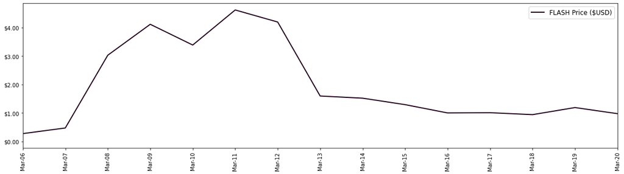

## Initial Price Spike

Due to low liquidity and immediate buying of FLASH, the price quickly spiked to over \$4.50 before settling down to around $1.00 as more liquidity was added, stabilizing the price.

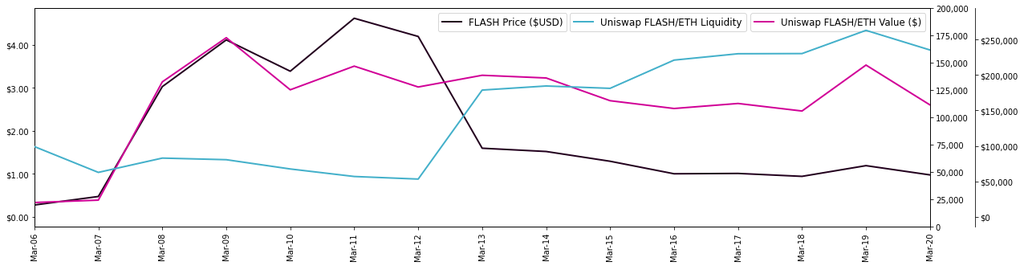

## Flash Staking

On the same day that a lot of liquidity was dumped into the Uniswap FLASH/ETH pool, nearly 80 stakes were executed with over 2 million $FLASH staked.

|  | Liquidity | Stake Count | Total Tokens Staked |
| --- | --- | --- | --- |
| 2021-03-13 | 125,151 | 77 | 2,045,963 |

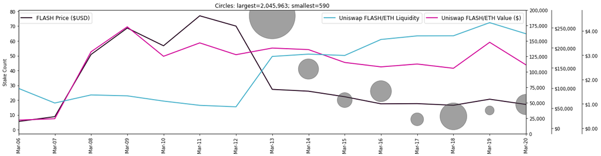

We can check to see how much overlap exists between accounts that added liquidity to Uniswap and staked on that same day.

|  | Account | Date | Liquidity (ETH) Deposited | $FLASH staked | Days Actually Staked |
| --- | --- | --- | --- | --- | --- |
| 0 | 0xaaf1eb836c73fe48fe67150bd5eb412deb39de23 | 2021-03-13 | 1.45 | 64,259 | 30.0 |
| 1 | 0x109cbb5f91951b29c025294ea2b8678ff1386d0e | 2021-03-13 | .26 | 5,696 | 118.0 |
| 2 | 0x588031347beaa0d43978bc8c0094138a67d1a071 | 2021-03-13 | .26 | 2,504 | 35.0 |
| 3 | 0x588031347beaa0d43978bc8c0094138a67d1a071 | 2021-03-13 | .26 | 631 | 35.0 |

## Staking / Price Stability

After this early spike in staking in early to mid March, staking stabilized at less than 10 stakes per day while the price of FLASH dropped to around \$0.60 by mid-April.

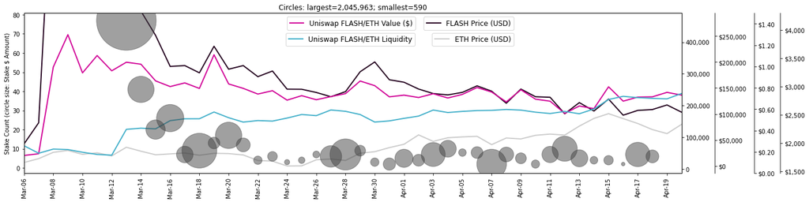

## May Peak

By the end of April, as the crypto market began its climb toward its May peak, the price of $FLASH rapidly rose and liquidity quickly pooled in Uniswap.

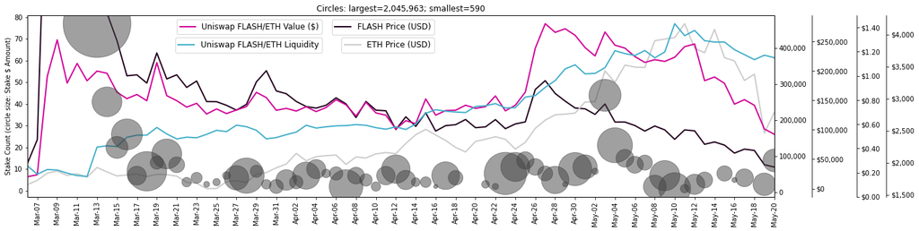

## Liquidity Delay

The price of \$FLASH quickly dropped after the late-April spike. However, Uniswap liquidity in the FLASH/ETH pool continued to rise along with the price of \\$ETH.

Just like the \$ETH price spike in May, the Uniswap FLASH/ETH liquidity did not last long, with liquidity gradually being withdrawn until mid-June, when low-levels of liquidity stabilized along with the price of \\$FLASH.

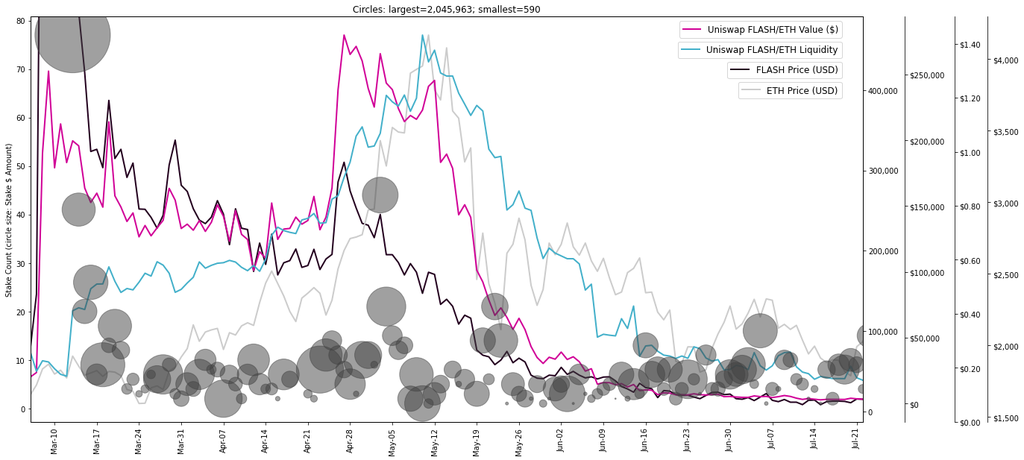

### ETH Correlation?

A natural question when considering the fate of V2 is whether the general crypto market played a role. Unfortunately, this analysis does not adequately examine this influence. Although a rough analysis of correlation does seem to show some related aspects (an R-squared valuation of > 0.7), this is not enough evidence to conclude that the price of \$ETH was the main determiner of liquidity in Uniswap or staking in Flash.

## July 31 V3 Deadline

If we zoom out to consider the entire Flash V2 period up through early September, we can see the July 31 deadline for establishing \$FLASH staking positions for the V3 consideration causing a spike in staking.

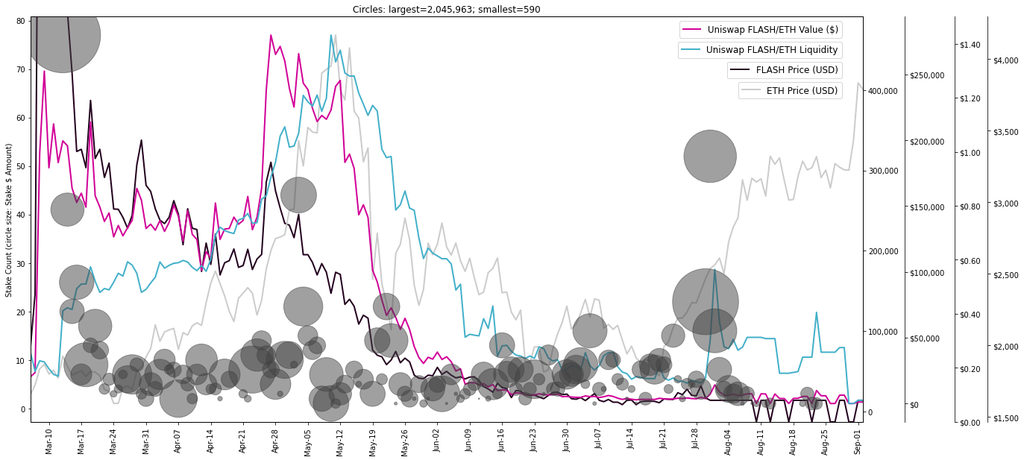

# Flash V2 User Behavior

Now let's consider the staking behavior of accounts, grouped by the little amount of information we can use to categorize them.

## Length of Staking & Unstaking Early

By tracking when a stake began, when it ended, and how much was lost due to unstaking early, we can see staking behavior patterns in the most intuitive way possible. We will group these behaviors by amount staked at the start for more visual clarity.

For all Stake Period graphs:

- Blue Hexagon = Stake Start
- Grey Hexagon = Stake Expired
- Black Hexagon = Early Unstake & Token Burn

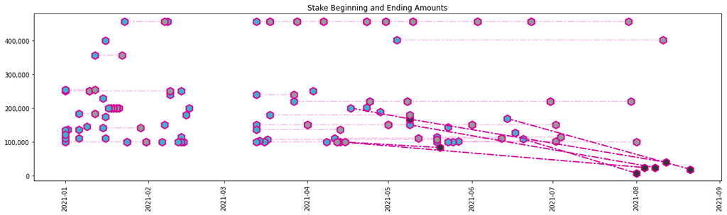

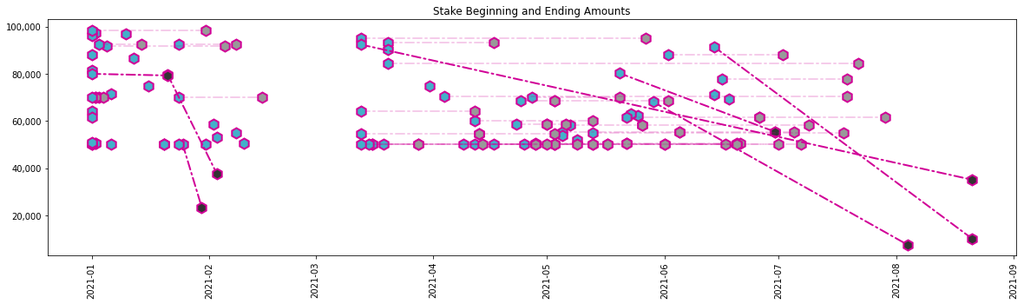

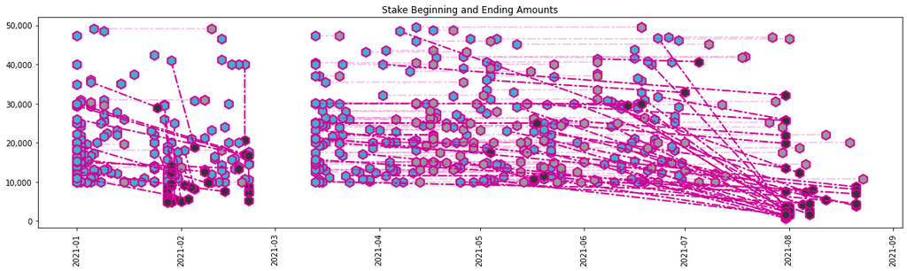

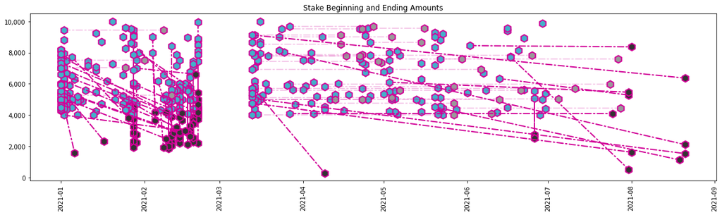

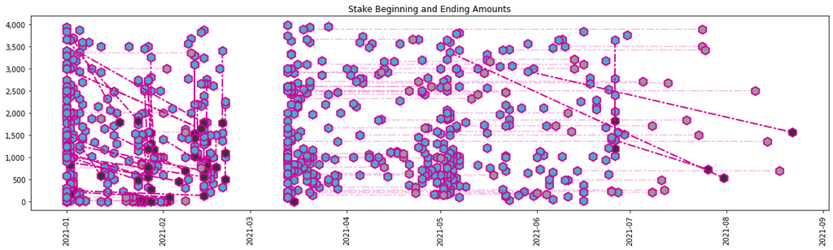

To view most of the data on a single chart, we can use a logarithmic scale. However, this graph is less intuitive since the visual distance between points is not a consistent value.

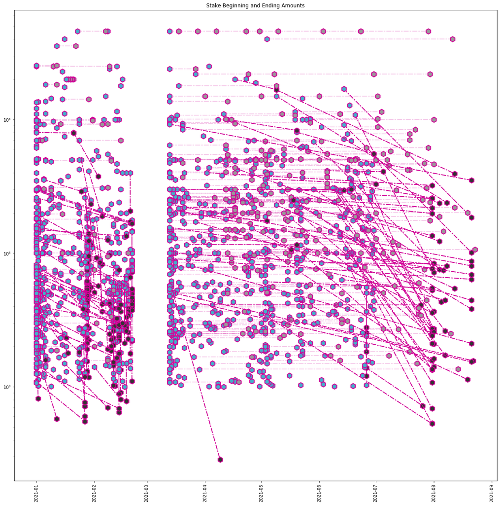

Unstaking early appears to mostly occur at milestones related to Flash version changes. Let's check that guess with a better summary analysis of unstakes, specifically early unstakes.

Note: We will only consider stakes before July 1. Activity after that period is either too recent or tainted by July 31 V3 deadline activity.

| Total Stakes | 1606 |
| --- | --- |
| Percent Unstaked | 35.6% |
| Percent Unstaked Early | 16.1% |
| Total Staked | 34,570,644 |
| Total Burned | 2,158,429 |
| Percent Burned | 6.2% |

So only about a third of stakes are unstaked and about half of those are unstaked early, leading to 6.2% of all staked amounts being burned.

Let's see a summary of when unstaking occurs. First we will look at data from days with many unstakes.

|  | Total Unstaked | Percent Unstaked Early | Total Burned | Percent Burned |
| --- | --- | --- | --- | --- |
| 2021-01-25 | 10 | 70.0% | 6,496 | 15.0% |
| 2021-01-28 | 26 | 100.0% | 105,584 | 52.7% |
| 2021-01-29 | 13 | 84.6% | 80,325 | 27.2% |
| 2021-02-11 | 13 | 92.3% | 28,812 | 48.8% |
| 2021-02-14 | 18 | 100.0% | 38,609 | 47.5% |
| 2021-02-21 | 18 | 100.0% | 79,872 | 46.2% |
| 2021-04-17 | 12 | 8.3% | 5 | .0% |
| 2021-07-31 | 22 | 100.0% | 250,694 | 58.2% |
| 2021-08-01 | 10 | 80.0% | 224,986 | 56.1% |
| 2021-08-21 | 11 | 100.0% | 370,110 | 77.8% |

The end of January, mid-late February, and around July 31 appear to be the hotspots.

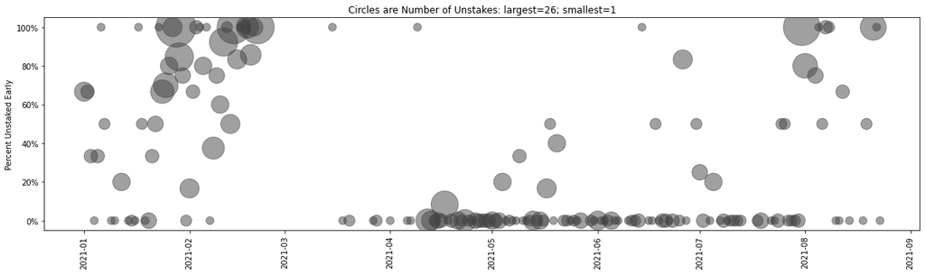

### Accounts that unstake early

Let's break out the accounts by total amount staked over Flash's lifetime to understand which ones unstake early.

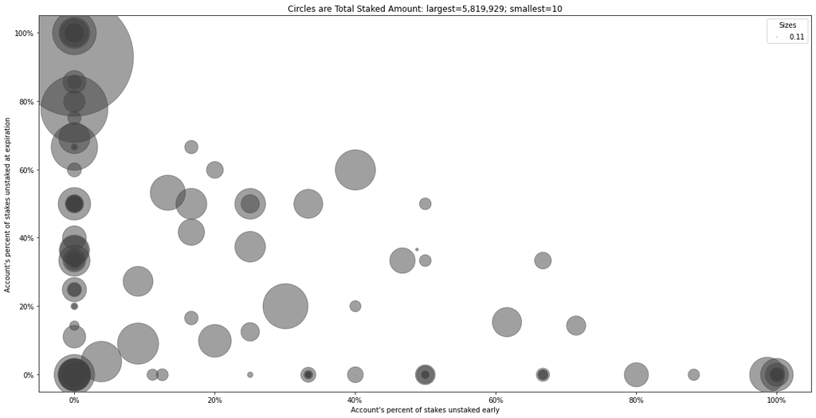

We can see that the accounts that tend to unstake early are not ones that stake a large amount of tokens.

## Old vs. New Accounts

Finally let's consider the behavior differences between older and newer accounts. We will also include V1 data for this analysis.

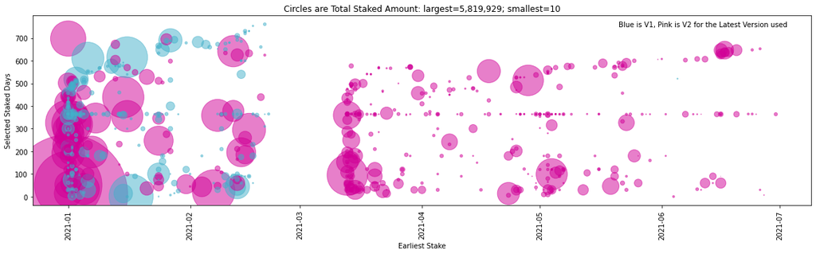

Accounts with more total staked and longer days staked appear during the V1 period. This might indicate a difference between the accounts interacting with V1 vs. V2, or more likely indicate that many V2 accounts also interacted with V1.

However, it does appear that newer accounts are more reluctant to commit to staking more over longer periods.

# Final Notes

This analysis is far from comprehensive. Additional analysis of user behavior and/or economic trends can reveal more actionable information for future versions of Flash.